# PS2 Labor Economics [2020]

R Version

Jonas Veit [jveit@mail.uni-mannheim.de]

# Estimating the intensive margin labor supply elasticity

Load helpful packages and the cps dataset

```r
library(tidyverse)
library(haven)
library(ggthemes)
library(dummies)
library(gridExtra)



cps = read_dta(file = '~/Documents/Programming/R/Labor Economics [2020]/Data for PS2/cps-1984-2010.dta')
```

### $a)$

```r
summary(cps)
```

```
##       year         statefip         metro            age           hrswork
##  Min.   :1984   Min.   : 1.00   Min.   :0.000   Min.   :16.00   Min.   : 0.0
##  1st Qu.:1991   1st Qu.:12.00   1st Qu.:2.000   1st Qu.:24.00   1st Qu.: 0.0
##  Median :1999   Median :27.00   Median :2.000   Median :29.00   Median :37.0
##  Mean   :1998   Mean   :27.48   Mean   :2.408   Mean   :29.92   Mean   :27.5
##  3rd Qu.:2005   3rd Qu.:39.00   3rd Qu.:3.000   3rd Qu.:36.00   3rd Qu.:40.0
##  Max.   :2010   Max.   :56.00   Max.   :4.000   Max.   :44.00   Max.   :99.0
##
##     uhrswork        incwage           nKids             mstat
##  Min.   : 0.00   Min.   :     0   Min.   : 0.0000   Min.   :1
##  1st Qu.:20.00   1st Qu.:  2430   1st Qu.: 0.0000   1st Qu.:1
##  Median :40.00   Median : 12016   Median : 0.0000   Median :1
##  Mean   :30.98   Mean   : 16715   Mean   : 0.6537   Mean   :1
##  3rd Qu.:40.00   3rd Qu.: 24000   3rd Qu.: 1.0000   3rd Qu.:1
##  Max.   :99.00   Max.   :713263   Max.   :12.0000   Max.   :1
##
##    avgtax_15k         emp_ind          edu_yrs          hsDrop
##  Min.   :-0.3804   Min.   :0.0000   Min.   : 1.00   Min.   :0.00
##  1st Qu.: 0.0000   1st Qu.:0.0000   1st Qu.:12.00   1st Qu.:0.00
##  Median : 0.0000   Median :1.0000   Median :12.00   Median :0.00
##  Mean   : 0.1347   Mean   :0.7442   Mean   :12.95   Mean   :0.15
##  3rd Qu.: 0.2404   3rd Qu.:1.0000   3rd Qu.:14.00   3rd Qu.:0.00
##  Max.   : 0.7400   Max.   :1.0000   Max.   :20.00   Max.   :1.00
##  NA's   :1763
##      hsGrad          bachelor         advanced            hisp
##  Min.   :0.0000   Min.   :0.0000   Min.   :0.00000   Min.   :0.0000
##  1st Qu.:0.0000   1st Qu.:0.0000   1st Qu.:0.00000   1st Qu.:0.0000
##  Median :0.0000   Median :0.0000   Median :0.00000   Median :0.0000
##  Mean   :0.3531   Mean   :0.1594   Mean   :0.05592   Mean   :0.1552
##  3rd Qu.:1.0000   3rd Qu.:0.0000   3rd Qu.:0.00000   3rd Qu.:0.0000
##  Max.   :1.0000   Max.   :1.0000   Max.   :1.00000   Max.   :1.0000
##
##     nonwhite
##  Min.   :0.0000
##  1st Qu.:0.0000
##  Median :0.0000
##  Mean   :0.2557
##  3rd Qu.:1.0000
##  Max.   :1.0000
##
```

```r
mean(cps$nKids)
```

```
## [1] 0.6536786
```

```r
mean(cps$hisp)
```

```
## [1] 0.1551964
```

The average number of childen is $0.653$

The share of hispanic women in this data is $15.5$%

### $b)$

```r
hourly_wage = cps$incwage / (52*cps$uhrswork)

mean(hourly_wage,na.rm = TRUE)
```

```
## [1] 10.09143
```

```r
sd(hourly_wage,na.rm = TRUE)
```

```
## [1] 13.27755
```

Since there are NaN’s in our hourly wage vector we have to use **na.rm = TRUE**  
$mean(hourly\_wage) = 10.091$  
$sd(houry\_wage) = 13.277$  
There are missing values because the column $uhrswork$ contains zero rows.  
Dividing by zero produces NaN’s. You can calculate the amount of zeros by executing the following command.

```r
sum(cps$uhrswork == 0)
```

```
## [1] 55727
```

Compare it with the number of NaN’s in the $hourly\_wage$ vector.

```r
sum(hourly_wage == 'NaN')
```

```
## [1] 55727
```

### $c)$

```r
mean(cps$emp_ind)
```

```
## [1] 0.7441964
```

```r
mean(cps$emp_ind[cps$nKids == 0])
```

```
## [1] 0.7859709
```

```r
mean(cps$emp_ind[cps$nKids == 1])
```

```
## [1] 0.7178345
```

```r
mean(cps$emp_ind[cps$nKids == 2])
```

```
## [1] 0.6774068
```

The overall rate of labor force participation is $74.41$%  
The rate of labor force participation among women who have no children is $78.59$%  
The rate for 1 children is $71.78$%  
The rate for 2 children is $67.74$  
The rate of labor force participation among women with 10 children is very high because of the amount of women who have 10 children.

```r
cps %>%
  filter(nKids == 10) %>%
  select(emp_ind)
```

```
## # A tibble: 10 x 1
##    emp_ind
##      <dbl>
##  1       1
##  2       0
##  3       1
##  4       0
##  5       1
##  6       0
##  7       1
##  8       1
##  9       1
## 10       0
```

we can clearly see that there are just 10 women with 10 children in this dataset and 6 of them are participating in the labor force i.e $60$%

### $d)$

we want to estimate the model
$$\textrm{uhrswork}_i = \beta_0 + \beta_1 \textrm{wage}_i + \varepsilon_i$$

```r
regression1 = lm(cps$uhrswork ~ hourly_wage);regression1
```

```
##
## Call:
## lm(formula = cps$uhrswork ~ hourly_wage)
##
## Coefficients:
## (Intercept)  hourly_wage
##    37.30545      0.06117
```

```r
sum_reg1 = summary(regression1);summary(regression1)[4]
```

```
## $coefficients
##                Estimate  Std. Error    t value Pr(>|t|)
## (Intercept) 37.30545282 0.024755393 1506.96265        0
## hourly_wage  0.06116711 0.001484384   41.20706        0
```

The estimate for $\hat{\beta}_1$ is $0.06117$  
The standard error for $\hat{\beta}_1$ is $0.00148$ and the t-statistic is $41.20$  
We can see that $Pr(>|t|)$ is $0$ that means our p-value is $\approx 0$  
According to the estimated $\hat{\beta}_1$ an one dollar increase in wage should result in an increase of hours worked of 0.0611  
Now estimate the elasticity of hours worked with respect to wage

```r
avg_hourly_wage = mean(hourly_wage,na.rm = TRUE)

avg_uhrswork = mean(cps$uhrswork)

regression1$coefficients[2]*(avg_hourly_wage/avg_uhrswork)
```

```
## hourly_wage
##  0.01992475
```

The estimated elasticity $e$ is equal to $0.0199 \approx 0.02$

### $e)$

Now we want to estimate the log regression
$$\log(\textrm{uhrswork}_i) = \beta_0 + \beta_1 \log(\textrm{wage}_i) + \varepsilon_i$$

```r
log_uhrswork = log(cps$uhrswork)
log_wage = log(hourly_wage)
log_regression1 = lm(log_uhrswork ~ log_wage);summary(log_regression1)[4]
```

```
## $coefficients
##               Estimate   Std. Error   t value Pr(>|t|)
## (Intercept) 3.42886100 0.0015026129 2281.9324        0
## log_wage    0.08245064 0.0006915774  119.2211        0
```

The estimate for $\hat{\beta}_1$ is $0.08245$  
The standard error for $\hat{\beta}_1$ is $0.00069$ and the t-statistic is $119.2211$  
We can see that $Pr(>|t|)$ is $0$ that means our p-value is $\approx 0$  
$e_{reg1} = 0.01992475$ vs. $e_{log(reg1)} = 0.08245$  
If the wage increases by $10\%$ hours worked would increase by $10 \times 0.08245\ = 0.8245\%$

### $f)$

I am combining $log\_wage$ and $age$ into one dataframe for easier usage.  
$log\_hours$ contains NaN’s that means that we have to use the command: **use = ‘complete.obs’**

```r
cov_dataframe = data.frame(log_wage,cps$age)
cov(cov_dataframe,use = 'complete.obs')
```

```
##           log_wage   cps.age
## log_wage 0.9775908  2.219258
## cps.age  2.2192582 55.105299
```

```r
0.0053*(cov(log_wage,cps$age,use = 'complete.obs')/var(log_wage,na.rm = TRUE))
```

```
## [1] 0.01203169
```

### $g)$

```r
log_regression1_with_age = lm(log_uhrswork ~ log_wage + cps$age);summary(log_regression1_with_age)[4]
```

```
## $coefficients
##                Estimate   Std. Error    t value Pr(>|t|)
## (Intercept) 3.291758419 0.0028809130 1142.60945        0
## log_wage    0.070317522 0.0007210634   97.51920        0
## cps$age     0.005344679 0.0000960407   55.65014        0
```

We get almost the same coefficients

### $h)$

We want to estimate the model
$$\log(\textrm{uhrswork}_i) = \beta_0 + \beta_1 \log(\textrm{wage}_i) +\beta_2\textrm{edu_years} + \beta_3\textrm{age} + \beta_4 \textrm{age}^2 + \beta_5 \textrm{year} + \beta_6 \textrm{hisp} + \beta_7\textrm{nonwhite} + \varepsilon_i$$

```r
age_squared = cps$age^2
log_regression2 = lm(data = cps,formula = log_uhrswork ~ log_wage + edu_yrs + age + age_squared + year + hisp + nonwhite);summary(log_regression2)[4]
```

```
## $coefficients
##                  Estimate   Std. Error    t value      Pr(>|t|)
## (Intercept)  7.9669260684 1.808884e-01  44.043322  0.000000e+00
## log_wage     0.0658059312 8.012065e-04  82.133545  0.000000e+00
## edu_yrs      0.0068864111 3.186811e-04  21.609098 1.837798e-103
## age          0.0414289574 8.681065e-04  47.723356  0.000000e+00
## age_squared -0.0005776172 1.382015e-05 -41.795297  0.000000e+00
## year        -0.0026475139 9.022448e-05 -29.343632 6.071673e-189
## hisp         0.0087558989 2.038250e-03   4.295792  1.741370e-05
## nonwhite    -0.0043099830 1.633346e-03  -2.638745  8.321867e-03
```

The estimated labor supply elasticity does not stay the same. We are now controlling for other variables. Therefore we are able to adress the omitted variable bias. The elasticity shrinks to 0.066  
Individuals with more education and who are older tend to work more. The coefficient on year is negative, suggesting people work fewer hours over time.

### $i)$

Here we create a new DataFrame with all women with no childen which we access in the $lm()$ command.
Moreover we create new vectors for $\log(wage)$ , $\log(uhrswork)$ and $\textrm{age}^2$ conditioned on $nKids == 0$
Note that I used a different approach to create the DataFrame and vectors using the package ‘dplyr’ which belongs to the ‘tidyverse’ package that we loaded at the beginning
We could have also used the following base-R commands:
$$\textrm{cps_nochildren = cps \$ [cps \$ nKids == 0,]}$$
$$\textrm{log_wage_nochildren} = \log(\textrm{cps_nochildren \$ incwage / (52*cps_nochildren \$ uhrswork}))$$
$$...$$
But using ‘dplyr’ makes the code much easier to read.

```r
cps_nochildren = cps %>%
  filter(nKids == 0)

log_wage_nochildren = cps %>%
  filter(nKids == 0) %>%
  select(incwage,uhrswork) %>%
  transmute(log(incwage/(52*uhrswork))) %>%
  pull()


log_uhrswork_nochildren = cps %>%
  filter(nKids == 0) %>%
  select(uhrswork) %>%
  transmute(log(uhrswork)) %>%
  pull()

age_squared_nochildren = cps_nochildren %>%
  select(age) %>%
  transmute(age^2) %>%
  pull()
```

```r
log_regression_nochildren = lm(data = cps_nochildren,formula = log_uhrswork_nochildren ~ log_wage_nochildren + edu_yrs + age + age_squared_nochildren + year + hisp + nonwhite);summary(log_regression_nochildren)[4]
```

```
## $coefficients
##                             Estimate   Std. Error    t value      Pr(>|t|)
## (Intercept)             7.3825885618 2.228902e-01  33.122084 9.006518e-240
## log_wage_nochildren     0.0607308414 1.031629e-03  58.868888  0.000000e+00
## edu_yrs                 0.0056710061 3.894322e-04  14.562244  5.234497e-48
## age                     0.0522317042 1.094430e-03  47.725031  0.000000e+00
## age_squared_nochildren -0.0007319627 1.758015e-05 -41.635743  0.000000e+00
## year                   -0.0024242484 1.111238e-04 -21.815753 2.329086e-105
## hisp                    0.0070801461 2.567271e-03   2.757849  5.818946e-03
## nonwhite               -0.0107246474 2.135577e-03  -5.021898  5.121722e-07
```

```r
cps_children = cps %>%
  filter(nKids > 0)

log_wage_children = cps %>%
  filter(nKids > 0) %>%
  select(incwage,uhrswork) %>%
  transmute(log(incwage/(52*uhrswork))) %>%
  pull()


log_uhrswork_children = cps %>%
  filter(nKids > 0) %>%
  select(uhrswork) %>%
  transmute(log(uhrswork)) %>%
  pull()

age_squared_children = cps_children %>%
  select(age) %>%
  transmute(age^2) %>%
  pull()
```

```r
log_regression_children = lm(data = cps_children,formula = log_uhrswork_children ~ log_wage_children + edu_yrs + age + age_squared_children + year + hisp + nonwhite);summary(log_regression_children)[4]
```

```
## $coefficients
##                           Estimate   Std. Error    t value      Pr(>|t|)
## (Intercept)           8.0387630635 3.198253e-01  25.134856 6.624775e-139
## log_wage_children     0.0703747285 1.284930e-03  54.769291  0.000000e+00
## edu_yrs               0.0048832735 6.024304e-04   8.105955  5.301691e-16
## age                   0.0223170162 1.601524e-03  13.934866  4.346224e-44
## age_squared_children -0.0002936544 2.465041e-05 -11.912759  1.077944e-32
## year                 -0.0025308304 1.587232e-04 -15.944926  3.736208e-57
## hisp                  0.0108243204 3.346730e-03   3.234298  1.219884e-03
## nonwhite              0.0092551585 2.563817e-03   3.609914  3.064729e-04
```

### $j)$

There are many possibilities here, the important thing is that you find a variable that is plausible and that you correctly figure out the direction of the bias.  
One example for an omitted variable may be how monotonous a job is. Suppose some jobs are inherently more monotonous and therefore boring than others. E.g. working at an assembly line vs. working as a photographer. Suppose monotonous jobs pay less. $Cov(Monotonous,Wage)<0$, and people want to work less in monotonous jobs, so that the direct effect of monotonous Cov(hours, Monotonous) is negative. From the omitted variable bias formula, we can see that the bias term would therefore be positive and therefore the estimated elasticity would likely be larger than the true elasticity.

# Minimum Wage Application

Load the corresponding dataset.

```r
dubelesterreich_minwage = read_dta(file = "~/Documents/Programming/R/Labor Economics [2020]/Data for PS2/dubelesterreich_minwage.dta")

dubelesterreich_empdata = read_dta(file = "~/Documents/Programming/R/Labor Economics [2020]/Data for PS2/dubelesterreich_empdata.dta")
```

### $1)$ Prepare the dataset

Create the meanwage vector and append it to the dataframe.

```r
minwage = rep(0,length(dubelesterreich_minwage$st_mw))

for (i in 1:length(t(minwage))){
  if (is.na(dubelesterreich_minwage$st_mw[i] == TRUE)){
    minwage[i] = dubelesterreich_minwage$fed_mw[i]
  } else if (dubelesterreich_minwage$st_mw[i] > dubelesterreich_minwage$fed_mw[i]){
    minwage[i] = dubelesterreich_minwage$st_mw[i]
  } else if (dubelesterreich_minwage$st_mw[i] == dubelesterreich_minwage$fed_mw[i]){
    minwage[i] = dubelesterreich_minwage$st_mw[i]
  } else {
    minwage[i] = dubelesterreich_minwage$fed_mw[i]
  }
}

minwage_clean = dubelesterreich_minwage %>%
  add_column(minwage)
```

```r
summary(dubelesterreich_minwage$st_mw)
```

```
##    Min. 1st Qu.  Median    Mean 3rd Qu.    Max.    NA's
##   3.350   4.650   5.750   5.579   6.500   7.930    3904
```

```r
summary(dubelesterreich_minwage$fed_mw)
```

```
##    Min. 1st Qu.  Median    Mean 3rd Qu.    Max.
##   3.350   3.350   4.250   4.421   5.150   5.850
```

```r
summary(minwage_clean$minwage)
```

```
##    Min. 1st Qu.  Median    Mean 3rd Qu.    Max.
##   3.350   3.800   4.450   4.602   5.150   7.930
```

### $a) \ \ \ \textrm{&} \ \ \ b)$

$\min = 3.350$  
$\max = 7.930$  
Save the minwage vector as a file.

```r
write_dta(as.data.frame(minwage_clean),path = "~/Documents/Programming/R/Labor Economics [2020]/minwage_clean.dta")
```

### $c)$

```r
mean_minwage = minwage_clean %>%
  group_by(year) %>%
  arrange(year) %>%
  summarise(mean = mean(minwage))

mean_fedwage = minwage_clean %>%
  group_by(year) %>%
  arrange(year) %>%
  summarise(mean_fed = mean(fed_mw))

mean_minwage_fed = data.frame(mean_fedwage,mean_minwage) %>%
  select(-year.1) %>%
  pivot_longer(cols = c("mean_fed","mean"));colnames(mean_minwage_fed)[3] = "means"

mean_minwage_plot = ggplot(mean_minwage) +
  geom_path(aes(x = year , y = mean),color = "dodgerblue4") +
  scale_x_continuous(breaks = scales::pretty_breaks(n = 5)) +
  scale_y_continuous(limits = c(3,7) , breaks = scales::breaks_pretty(n = 5)) +
  ggtitle(label = "Average minimum wage by year") +
  ylab("") +
  xlab("Year") +
  theme_stata()

mean_fed_minwage_plot = ggplot(mean_minwage_fed,aes(color = name)) +
  geom_path(aes(x = year , y = means)) +
  scale_x_continuous(breaks = scales::pretty_breaks(n = 5)) +
  scale_y_continuous(limits = c(3,7) , breaks = scales::pretty_breaks(n = 5)) +
  ylab(label ="") +
  xlab(label = "Year") +
  ggtitle(label = "Average minimum wage and federal minimum wage by year") +
  scale_color_manual(name="",labels=c("Average minimum wage","Federal minimum wage"),values=c("dodgerblue4","red")) +
  theme_stata()
```

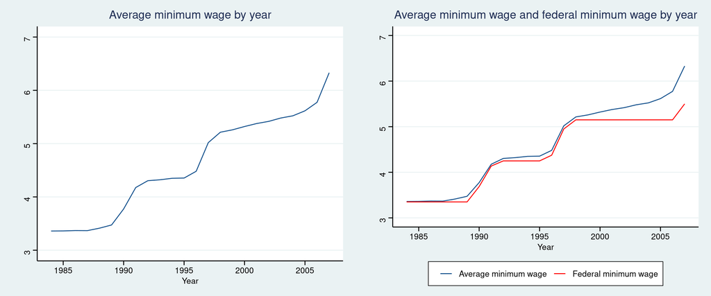

```r
grid.arrange(mean_minwage_plot , mean_fed_minwage_plot ,ncol = 2)
```

### $d)$

Filter for year == 2000

```r
dubelesterreich_empdata_2000 = dubelesterreich_empdata %>%
  filter(year == 2000)


mean_emp_rest = dubelesterreich_empdata_2000 %>%
  group_by(state) %>%
  arrange(state) %>%
  summarise(mean_emp_rest = mean(emp_rest))

mean_emp_tot = dubelesterreich_empdata_2000 %>%
  group_by(state) %>%
  arrange(state) %>%
  summarise(mean_emp_tot = mean(emp_tot))

mean_emp_totemp = data.frame(mean_emp_rest,mean_emp_tot) %>%
  select(-c("state","state.1"))

mean_emp_totemp_plot = ggplot(mean_emp_totemp) +
  geom_point(aes(x = mean_emp_tot , y = mean_emp_rest),color = "dodgerblue4") +
  scale_x_continuous(breaks = scales::breaks_pretty(n = 5) , labels = scales::comma) +
  theme_stata()
```

```r
logmean_emp_rest = dubelesterreich_empdata_2000 %>%
  group_by(state) %>%
  arrange(state) %>%
  summarise(logmean_emp_rest = mean(logemp_rest))

logmean_emp_tot = dubelesterreich_empdata_2000 %>%
  group_by(state) %>%
  arrange(state) %>%
  summarise(logmean_emp_tot = mean(logemp_tot))

logmean_emp_totemp = data.frame(logmean_emp_rest,logmean_emp_tot) %>%
  select(-c("state","state.1"))

logmean_emp_totemp_plot = ggplot(logmean_emp_totemp) +
  geom_point(aes(x = logmean_emp_tot , y = logmean_emp_rest),color = "dodgerblue4") +
  scale_x_continuous(breaks = scales::breaks_pretty(n = 5)) +
  theme_stata()
```

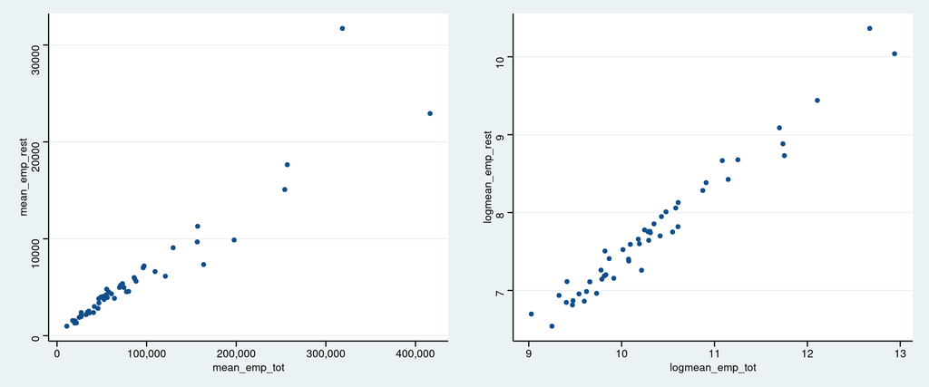

```r
grid.arrange(mean_emp_totemp_plot , logmean_emp_totemp_plot , ncol = 2)
```

### $e)$

```r
regression1 = lm(data = dubelesterreich_empdata , formula = emp_rest ~ emp_tot);summary(regression1)
```

```
##
## Call:
## lm(formula = emp_rest ~ emp_tot, data = dubelesterreich_empdata)
##
## Residuals:
##    Min     1Q Median     3Q    Max
## -50182   -505   -292    256  44017
##
## Coefficients:
##              Estimate Std. Error t value Pr(>|t|)
## (Intercept) 5.268e+02  7.796e+00   67.57   <2e-16 ***
## emp_tot     5.972e-02  4.219e-05 1415.29   <2e-16 ***
## ---
## Signif. codes:  0 '***' 0.001 '**' 0.01 '*' 0.05 '.' 0.1 ' ' 1
##
## Residual standard error: 2194 on 91059 degrees of freedom
##   (19 observations deleted due to missingness)
## Multiple R-squared:  0.9565, Adjusted R-squared:  0.9565
## F-statistic: 2.003e+06 on 1 and 91059 DF,  p-value: < 2.2e-16
```

```r
regression2 = lm(data = dubelesterreich_empdata , formula = logemp_rest ~ logemp_tot);summary(regression2)
```

```
##
## Call:
## lm(formula = logemp_rest ~ logemp_tot, data = dubelesterreich_empdata)
##
## Residuals:
##      Min       1Q   Median       3Q      Max
## -2.24153 -0.18621  0.00845  0.18768  1.23950
##
## Coefficients:
##               Estimate Std. Error t value Pr(>|t|)
## (Intercept) -2.1100781  0.0077914  -270.8   <2e-16 ***
## logemp_tot   0.9515609  0.0007666  1241.3   <2e-16 ***
## ---
## Signif. codes:  0 '***' 0.001 '**' 0.01 '*' 0.05 '.' 0.1 ' ' 1
##
## Residual standard error: 0.2971 on 91059 degrees of freedom
##   (19 observations deleted due to missingness)
## Multiple R-squared:  0.9442, Adjusted R-squared:  0.9442
## F-statistic: 1.541e+06 on 1 and 91059 DF,  p-value: < 2.2e-16
```

**Regression 1:**  
for each additional job in a county there are about 0.059 additional restaurants  
with a t-value of $1415.29$ the coefficient is statistically significant  
**Regression 2:**  
If employment goes up by one percent restaurant employment goes up by $\approx 1$ percent

### $f)$

```r
minwage_clean = minwage_clean %>%
  select(state,period,minwage)

dubelesterreich_empdata = merge(dubelesterreich_empdata,minwage_clean,by = c("state","period"))


dubelesterreich_empdata_minwage = dubelesterreich_empdata %>%
  mutate(minwage = replace(minwage,year == 2004 & county == 6075,8.5)) %>%
  mutate(minwage = replace(minwage,year == 2005 & county == 6075,8.62)) %>%
  mutate(minwage = replace(minwage,year == 2006 & county == 6075, 8.82)) %>%
  mutate(logminwage = log(minwage))

write_dta(dubelesterreich_empdata , path = "~/Documents/Programming/R/Labor Economics [2020]/dubelesterreich_empdata_minwage.dta")
```

# Estimating the Effect of Minimum Wages

### $a)$

Equation $(1)$ in the Dube, Lester and Reich article is the following
$$\ln_{it} = \alpha + \eta\ln(MW_{it}) + \delta\ln(y_{it})^{TOT} + \gamma\ln(pop_{it}) + \phi_i + \tau_t + \varepsilon_{it}$$
First we want to estimate

$$\log(\textrm{earnings_rest}) = \alpha + \eta\log(\textrm{minwage}) + \delta\log(\textrm{earnings_tot}) + \varepsilon_{it}$$

```r
log_regression1 = lm(data = dubelesterreich_empdata_minwage, formula = logearnings_rest ~ logminwage + logearnings_tot);log_regression1
```

```
##
## Call:
## lm(formula = logearnings_rest ~ logminwage + logearnings_tot,
##     data = dubelesterreich_empdata_minwage)
##
## Coefficients:
##     (Intercept)       logminwage  logearnings_tot
##          1.0723           0.5460           0.5181
```

```r
summary(log_regression1)[4]
```

```
## $coefficients
##                  Estimate  Std. Error   t value Pr(>|t|)
## (Intercept)     1.0722681 0.012498330  85.79291        0
## logminwage      0.5460275 0.004748143 114.99812        0
## logearnings_tot 0.5181051 0.002427013 213.47443        0
```

### $b)$

Since there is a multicollinearity issue within the period columns R will omit one of the variables so that $(\mathrm{X'X})^{-1}$ is invertible.  
In the solution sheet STATA omitted the variable ‘period64’. To recreate the same coefficients I have also removed the variable ‘period64’ from the dummy dataframe.

```r
dummy_dataframe_period = as.data.frame(dummy(dubelesterreich_empdata_minwage$period));colnames(dummy_dataframe_period) = paste("period" , 1:66 , sep = "")
dummy_regression1 = lm(data = select(dummy_dataframe_period,-period64),formula = dubelesterreich_empdata_minwage$logearnings_rest ~ dubelesterreich_empdata_minwage$logminwage + dubelesterreich_empdata_minwage$logearnings_tot + .);dummy_regression1$coefficients[c(2,3,4)]
```

```
##      dubelesterreich_empdata_minwage$logminwage
##                                     0.532471886
## dubelesterreich_empdata_minwage$logearnings_tot
##                                     0.502101718
##                                         period1
##                                     0.003473719
```

I didn’t print out every coefficient. You can do that by running: ‘$dummy\_regression1\$coefficients$’  
Now we want to include the county fixed effects.  
Note that we could use the same procedure as before. This would take relatively long to compute and is memory heavy.  
The corresponding code would be :

$$\textrm{dummy_dataframe_county = as.data.frame(dummy(dubelesterreich_empdata_minwage\$county))}$$
$$\textrm{dummy_dataframe_county_period = data.frame(dummy_dataframe_period , dummy_dataframe_county)
}$$
$$\textrm{dummy_reg_county_period = lm(data = dummy_dataframe_county_period , formula =}$$
$$\textrm{dubelesterreich_empdata_minwage\$logearnings_rest ~ dubelesterreich_empdata_minwage\$logminwage +}$$
$$\textrm{dubelesterreich_empdata_minwage\$logearnings_tot + .)}$$
Using the package $plm$ makes this computation much faster and easier.

```r
library(plm)
dummy_regression_period_county = plm(logearnings_rest ~ logminwage + logearnings_tot + dummy(period) , data=dubelesterreich_empdata_minwage, model="with" , index = "county")
dummy_regression_period_county$coefficients[c(1,2)]
```

```
##      logminwage logearnings_tot
##       0.2165587       0.1940754
```

# Unemployment Insurance Extension

Load the dataset

```r
UI_RD = read_dta(file = "~/Documents/Programming/R/Labor Economics [2020]/Data for PS2/UI_RD.dta")
```

### 1. Descriptive Analysis

$a)$

```r
summary(UI_RD)
```

```
##    birthdate         begindate          year          unemp
##  Min.   :-9490.0   Min.   : 9862   Min.   :1987   Min.   : 5.867
##  1st Qu.:-4240.0   1st Qu.:11960   1st Qu.:1992   1st Qu.: 7.792
##  Median :-2012.0   Median :14060   Median :1998   Median : 9.442
##  Mean   :-2008.5   Mean   :14060   Mean   :1998   Mean   : 9.197
##  3rd Qu.:  216.2   3rd Qu.:16160   3rd Qu.:2004   3rd Qu.:10.517
##  Max.   : 5457.0   Max.   :18262   Max.   :2009   Max.   :11.725
##
##     chgunemp        realgdpgrowthf1       age           agedays
##  Min.   :-1.75000   Min.   :-4.835   Min.   :35.00   Min.   :12783
##  1st Qu.:-0.67500   1st Qu.: 0.983   1st Qu.:39.00   1st Qu.:14423
##  Median :-0.10833   Median : 1.873   Median :43.00   Median :16068
##  Mean   : 0.01128   Mean   : 1.746   Mean   :43.49   Mean   :16068
##  3rd Qu.: 0.72500   3rd Qu.: 3.159   3rd Qu.:48.00   3rd Qu.:17711
##  Max.   : 1.87500   Max.   : 5.122   Max.   :52.00   Max.   :19358
##                     NA's   :18133
##   expbaseline           P           durnonemp           duruib
##  Min.   : 12.00   Min.   : 6.00   Min.   :-15.056   Min.   :-15.056
##  1st Qu.: 38.00   1st Qu.:12.00   1st Qu.:  4.792   1st Qu.:  4.792
##  Median : 52.00   Median :16.00   Median :  8.076   Median :  7.750
##  Mean   : 51.21   Mean   :16.71   Mean   :  8.694   Mean   :  7.845
##  3rd Qu.: 64.00   3rd Qu.:22.00   3rd Qu.: 11.457   3rd Qu.: 10.926
##  Max.   :148.00   Max.   :26.00   Max.   :164.825   Max.   : 26.000
##
##      edyrs          female           nonger            tenure
##  Min.   : 8.0   Min.   :0.0000   Min.   :0.00000   Min.   : 0.000
##  1st Qu.: 9.0   1st Qu.:0.0000   1st Qu.:0.00000   1st Qu.: 1.723
##  Median :11.0   Median :0.0000   Median :0.00000   Median : 4.162
##  Mean   :11.5   Mean   :0.3508   Mean   :0.07942   Mean   : 6.002
##  3rd Qu.:13.0   3rd Qu.:1.0000   3rd Qu.:0.00000   3rd Qu.: 8.323
##  Max.   :15.0   Max.   :1.0000   Max.   :1.00000   Max.   :86.496
##
```

$b)$

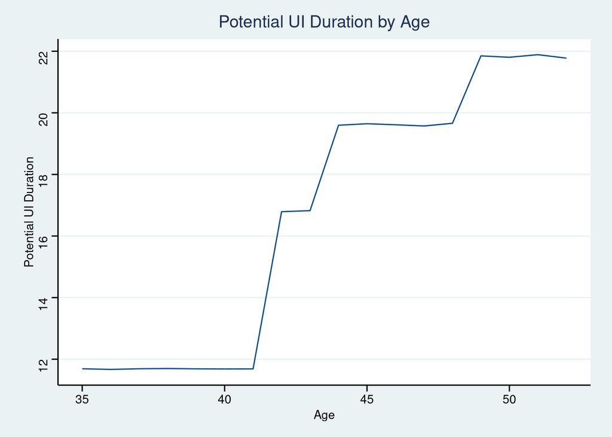

```r
ui_p_mean_per_age = UI_RD %>%
  group_by(age) %>%
  summarise(mean_P = mean(P))

ui_p_mean_per_age_plot = ggplot(data = ui_p_mean_per_age) +
  geom_line(aes(x = age , y = mean_P ),color = "dodgerblue4") +
  xlab("Age") +
  ylab("Potential UI Duration") +
  ggtitle(label = "Potential UI Duration by Age") +
  scale_y_continuous(breaks = scales::breaks_pretty(n = 5)) +
  theme_stata()

ui_p_mean_per_age_plot
```

$c)$

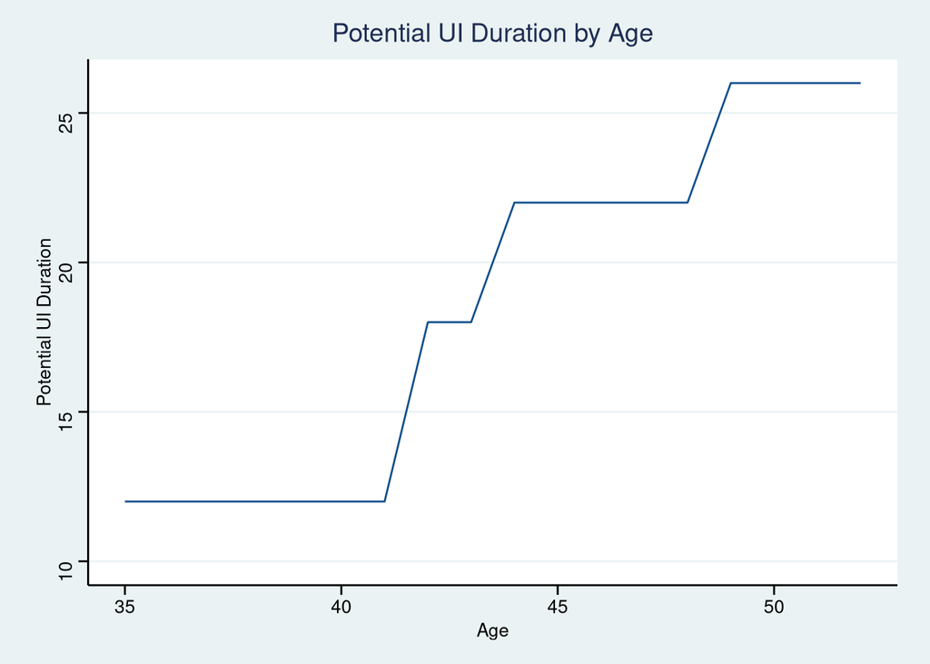

```r
ui_p_mean_per_age_exp52 = UI_RD %>%
  filter(expbaseline >= 52) %>%
  group_by(age) %>%
  summarise(mean_P = mean(P))

ui_p_mean_per_age_exp52_plot = ggplot(data = ui_p_mean_per_age_exp52) +
  geom_line(aes(x = age , y = mean_P ),color = "dodgerblue4") +
  xlab("Age") +
  ylab("Potential UI Duration") +
  ggtitle(label = "Potential UI Duration by Age") +
  scale_y_continuous(breaks = c(10,15,20,25),limits = c(10,26)) +
  theme_stata()

ui_p_mean_per_age_exp52_plot
```

### 2. OLS Analysis

$a)$

```r
library(estout)
UI_regression1 = lm(data = UI_RD , formula = durnonemp ~ P)
UI_regression2 = lm(data = UI_RD , formula = durnonemp ~ P + agedays)
UI_regression3 = lm(data = UI_RD , formula = durnonemp ~ P + agedays + edyrs + female + nonger + tenure)
UI_regression4 = lm(data = UI_RD , formula = durnonemp ~ P + agedays + edyrs + female + nonger + tenure + realgdpgrowthf1 + unemp)
```

Here I use the package $estout$ to export a $\LaTeX$ regression table.  
I exported the table and included it as an image in this document.

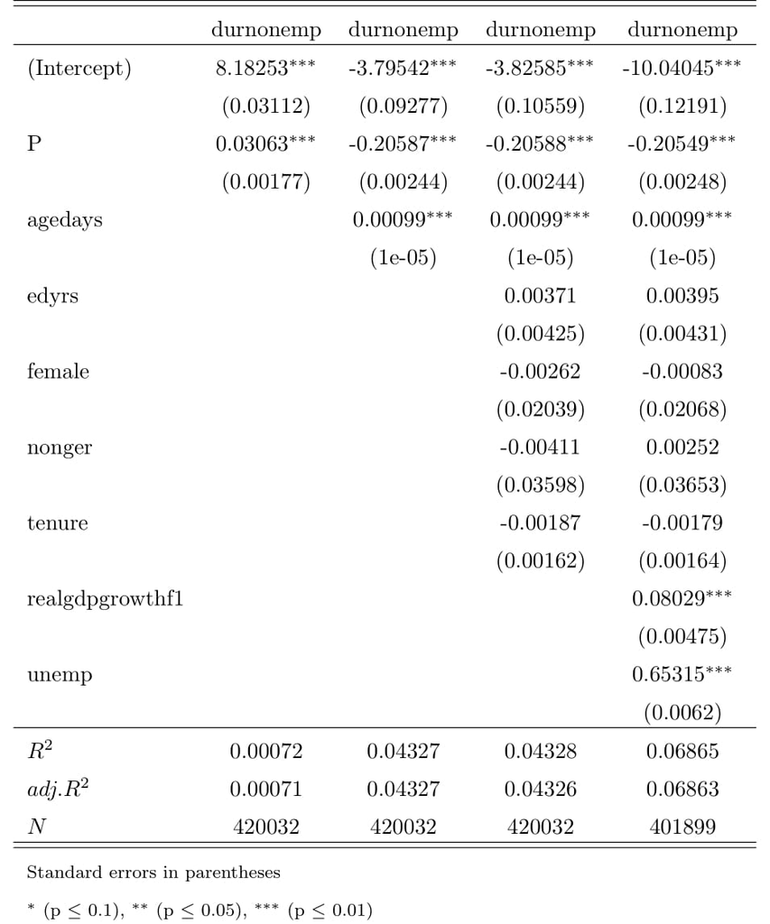

```r
estclear()
eststo(UI_regression1)
eststo(UI_regression2)
eststo(UI_regression3)
eststo(UI_regression4)
esttab(round.dec = 5 ,filename = "/home/jonas/Documents/Programming/R/Labor Economics [2020]/UI_table")
```

$b)$  
Including Age in the regression changes the $\beta_P$ coefficient from positive to negative.  
An additional month of UI would reduce the unemployement duration by 0.2 month. This is the opposite of what theory would predict  
$c)$  
Note that potential UI duration might be related to positive worker characteristics. Worker who are older and had more employment in the past 7 years (one of the criteria to be eligible for higher P) might be more employable in general and might have an easier time finding a job.

### 3. Regression Discontinuity Design

$a)$

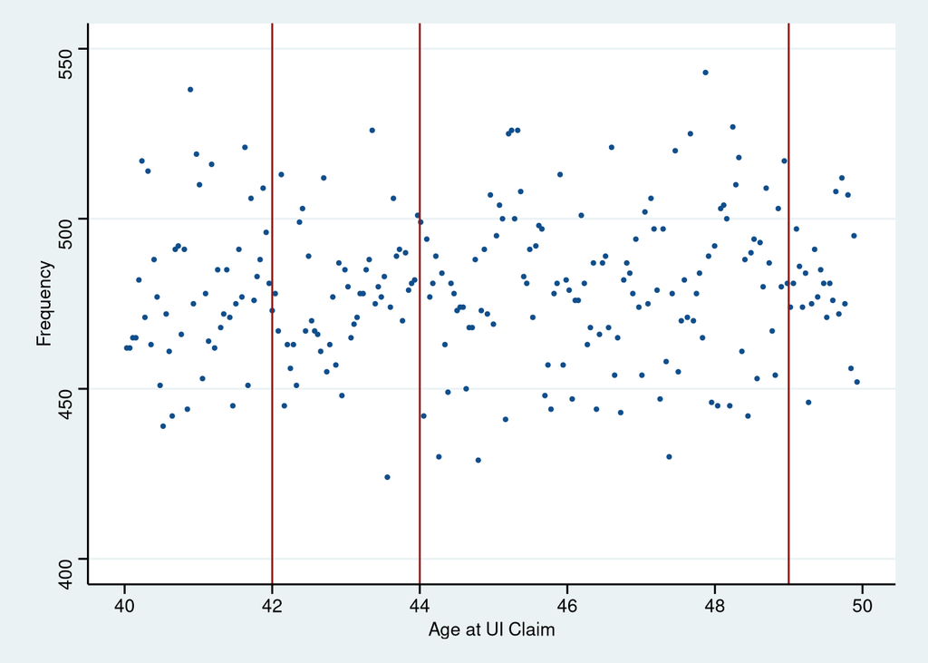

```r
uidata_temp = UI_RD %>%
  filter(expbaseline >= 52)


agebins = floor((uidata_temp$agedays - (42*365.25))/15)/(365.25/15)+42

N = rep(1,length(agebins))

uidata_temp_density = uidata_temp %>%
  add_column(agebins,N) %>%
  select(durnonemp,duruib,age,agebins,N) %>%
  group_by(agebins) %>%
  summarise(mean_durnonemp = mean(durnonemp),
            mean_duruib = mean(duruib),
            mean_age = mean(age) ,
            n = sum(N))


ggplot(data = uidata_temp_density) +
  geom_point(aes(x = agebins, y = n),color = "dodgerblue4" , size = 0.75) +
  scale_y_continuous(limits = c(400,550)) +
  scale_x_continuous(limits = c(40,49.95),breaks = scales::breaks_pretty(n = 6)) +
  geom_vline(xintercept = c(42,44,49),color = "firebrick4",size = 0.5) +
  xlab("Age at UI Claim") +
  ylab("Frequency") +
  theme_stata()
```

$b)$

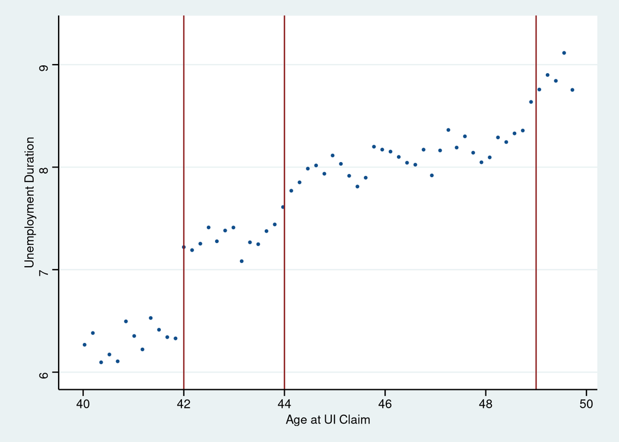

```r
agebins2 = floor((uidata_temp$agedays - (42*365.25))/60)/(365.25/60)+42

uidata_temp_density2 = uidata_temp %>%
  add_column(agebins2,N) %>%
  select(durnonemp,duruib,age,agebins2,N) %>%
  group_by(agebins2) %>%
  summarise(mean_durnonemp = mean(durnonemp),
            mean_duruib = mean(duruib),
            mean_age = mean(age) ,
            n = sum(N))

ggplot(data = uidata_temp_density2) +
  geom_point(aes(x = agebins2, y = mean_durnonemp),color = "dodgerblue4" , size = 0.75) +
  geom_vline(xintercept = c(42,44,49),color = "firebrick4", size = 0.5) +
  scale_x_continuous(limits = c(40,49.73) , breaks = scales::breaks_pretty(n = 6)) +
  xlab("Age at UI Claim") +
  ylab("Unemployment Duration") +
  theme_stata()
```

```r
uidata_temp_density3 = uidata_temp %>%
  add_column(agebins2,N) %>%
  select(durnonemp,duruib,age,expbaseline,edyrs,female,tenure,agebins2,N) %>%
  group_by(agebins2) %>%
  summarise(mean_durnonemp = mean(durnonemp),
            mean_duruib = mean(duruib),
            mean_age = mean(age),
            mean_expbaseline = mean(expbaseline),
            mean_edyrs = mean(edyrs),
            mean_female = mean(female),
            mean_tenure = mean(tenure),
            n = sum(N))

plot_expbaseline = ggplot(data = uidata_temp_density3) +
  geom_point(aes(x = agebins2, y = mean_expbaseline),color = "dodgerblue4" , size = 0.75) +
  geom_vline(xintercept = c(42,44,49),color = "firebrick4",size = 0.5) +
  scale_x_continuous(limits = c(40,49.73) , breaks = scales::breaks_pretty(n = 6)) +
  scale_y_continuous(limits = c(66,67.51) , breaks = scales::breaks_pretty(n = 4)) +
  xlab("Age at UI Claim") +
  ylab("Number of Months worked in previous 7 years") +
  theme_stata()


plot_edyrs = ggplot(data = uidata_temp_density3) +
  geom_point(aes(x = agebins2, y = mean_edyrs),color = "dodgerblue4" , size = 0.75) +
  geom_vline(xintercept = c(42,44,49),color = "firebrick4",size = 0.5) +
  scale_x_continuous(limits = c(40,49.73) , breaks = scales::breaks_pretty(n = 6)) +
  scale_y_continuous(limits = c(11.35,11.625) , breaks = scales::breaks_pretty(n = 6)) +
  ylab("Years of Schooling") +
  theme_stata()

plot_female = ggplot(data = uidata_temp_density3) +
  geom_point(aes(x = agebins2, y = mean_female),color = "dodgerblue4" , size = 0.75) +
  geom_vline(xintercept = c(42,44,49),color = "firebrick4",size = 0.5) +
  scale_x_continuous(limits = c(40,49.73) , breaks = scales::breaks_pretty(n = 6)) +
  scale_y_continuous(limits = c(0.32,0.381), breaks = scales::breaks_pretty(n = 4)) +
  xlab("Age at UI Claim") +
  ylab("Female") +
  theme_stata()

plot_tenure = ggplot(data = uidata_temp_density3) +
  geom_point(aes(x = agebins2, y = mean_tenure),color = "dodgerblue4" , size = 0.75) +
  geom_vline(xintercept = c(42,44,49),color = "firebrick4",size = 0.5) +
  scale_x_continuous(limits = c(40,49.73) , breaks = scales::breaks_pretty(n = 6)) +
  scale_y_continuous(limits = c(5.6,6.4) , breaks = scales::breaks_pretty(n = 5)) +
  xlab("Age at UI Claim") +
  ylab("Tenure at last Employer") +
  theme_stata()
```

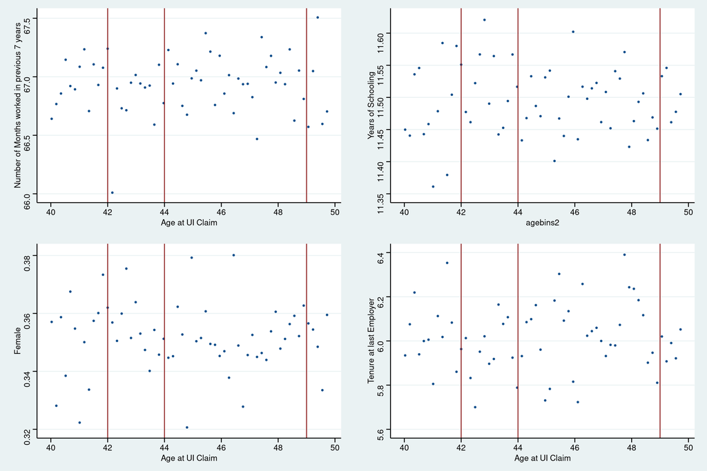

```r
grid.arrange(plot_expbaseline,plot_edyrs,plot_female,plot_tenure, nrow = 2,ncol = 2)
```

$d)$

```r
ui_data_age = UI_RD %>%
  filter(age >= 40 & age < 44 & expbaseline >= 52) %>%
  mutate(a0 = agedays-(42*365.25)) %>%
  mutate(RD = as.numeric(age >= 42)) %>%
  mutate(a1 = a0 * RD)

UI_regression5 = lm(data = ui_data_age , formula = durnonemp ~ P + a0 + a1);summary(UI_regression5)
```

```
##
## Call:
## lm(formula = durnonemp ~ P + a0 + a1, data = ui_data_age)
##
## Residuals:
##     Min      1Q  Median      3Q     Max
## -19.562  -3.438  -0.608   2.451  81.241
##
## Coefficients:
##               Estimate Std. Error t value Pr(>|t|)
## (Intercept)  4.7564544  0.2642429  18.000  < 2e-16 ***
## P            0.1379493  0.0173000   7.974 1.57e-15 ***
## a0           0.0002820  0.0001740   1.620    0.105
## a1          -0.0001433  0.0002462  -0.582    0.560
## ---
## Signif. codes:  0 '***' 0.001 '**' 0.01 '*' 0.05 '.' 0.1 ' ' 1
##
## Residual standard error: 5.603 on 46527 degrees of freedom
## Multiple R-squared:  0.007675,   Adjusted R-squared:  0.007611
## F-statistic:   120 on 3 and 46527 DF,  p-value: < 2.2e-16
```